# S:H cell ratios in Ofav [Control vs NH4]

Ana Palacio-Castro

October 1, 2016

### General project set-up

```r
    getwd()
```

```
## [1] "/home/frida/Dropbox/RSMAS/Projects/2016-LaurenOfav/Ofav-Ratios-R"
```

```r
    # Get all libraries and sources required to run the script
        source("STEPoneFunction.R")# R.Cunning steponeR function
        library(plyr)
        library(reshape2)
        library(ggplot2)
        library(lme4)
        library(lmerTest)
```

## ———————————————————————————

## 1. Calculate qPCR RATIOS

Get the raw data for Ofav R.Cunning steponeR function:

- Get list of plate files to read
- Calculate the ratios
- Extract the results

```r
  Ofav.plates <- list.files(path="data", pattern="csv", full.names=T)
  # Ofav.plates


  # Run stepone function to get Ratios

  Ofav.Out <- steponeR(files=Ofav.plates, target.ratios=c("A.Ofav", "B.Ofav","C.Ofav", "D.Ofav"),
                       fluor.norm=list(A=-0.064, B=4.197, C=3.798, D=0, Ofav=7.416),
                       copy.number=list(A=1, B=1,C=50, D=3, Ofav=14),
                       ploidy=list(A=1, B=1, C=1, D=1, Ofav=2),
                       extract=list(A=0.813, B=0.813, C=0.813, D=0.813, Ofav=0.982))

  # Target ratio results
  Ofav<-Ofav.Out$result
```

### Data CLEANING part A

```r
    # 1. Check and remove NTC wells

    ntc <- Ofav[which(Ofav$Sample.Name=="NTC"), ]
    Ofav <- droplevels(Ofav[!rownames(Ofav) %in% rownames(ntc), ])

    # 2. Check and remove + Control wells

    Positive <- Ofav[which(Ofav$Sample.Name=="Control"), ]
    Ofav <- droplevels(Ofav[!rownames(Ofav) %in% rownames(Positive), ])
```

### Calculate total S/H ratio, clade specific ratios and clade (D) proportion

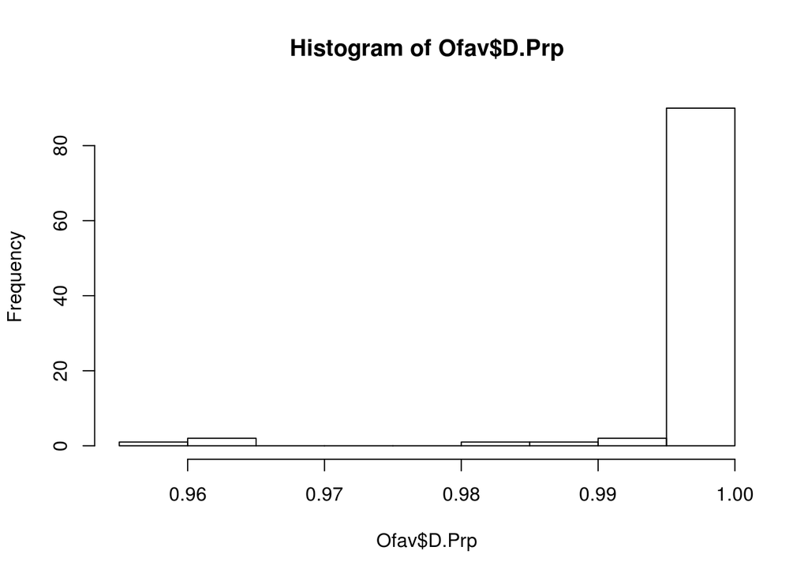

```r
# 1. If Clade only detected in one technical replicate, set its ratio to NA (becomes zero)
    Ofav$A.Ofav[which(Ofav$A.reps==1)] <- NA
    Ofav$B.Ofav[which(Ofav$B.reps==1)] <- NA
    Ofav$C.Ofav[which(Ofav$C.reps==1)] <- NA
    Ofav$D.Ofav[which(Ofav$D.reps==1)] <- NA

# 2. Rename cols and make NA=0
    colnames(Ofav)[which(colnames(Ofav) %in% c("A.Ofav", "B.Ofav","C.Ofav", "D.Ofav" ))] <- c("A.SH", "B.SH","C.SH", "D.SH")

    Ofav$A.SH[is.na(Ofav$A.SH)] <- 0
    Ofav$B.SH[is.na(Ofav$B.SH)] <- 0
    Ofav$C.SH[is.na(Ofav$C.SH)] <- 0
    Ofav$D.SH[is.na(Ofav$D.SH)] <- 0

# 3. Get the ratios and log 10
    # Total ratio
    Ofav$tot.SH <- Ofav$A.SH + Ofav$B.SH + Ofav$C.SH + Ofav$D.SH
    Ofav$logTot.SH <- log10(Ofav$tot.SH )  # Calculate log10 SH ratio

    # A LOG10 ratio
        Ofav$logA.SH <- log10(Ofav$A.SH)
    # B LOG10 ratio
        Ofav$logB.SH <- log10(Ofav$B.SH)
    # C LOG10 ratio
        Ofav$logC.SH <- log10(Ofav$C.SH)
    # D LOG10 ratio
        Ofav$logD.SH <- log10(Ofav$D.SH)

      Ofav$logTot.SH[which(Ofav$tot.SH==0)] <- NA
      Ofav$logA.SH[which(Ofav$A.SH==0)] <- NA
      Ofav$logB.SH[which(Ofav$B.SH==0)] <- NA
      Ofav$logC.SH[which(Ofav$C.SH==0)] <- NA
      Ofav$logD.SH[which(Ofav$D.SH==0)] <- NA

# 4. Clade Proportion
      # D Proportion
      Ofav$D.Prp<-(Ofav$D.SH/Ofav$tot.SH)
      D.Pro<-hist(Ofav$D.Prp)
```

All the cores are cleary dominated by D symbionts, so I won’t perform any analysis splitting the cores by clade and will use the total SH cell ratio, assuming this is basically D.

### DATA CLEANING part B

3. Check and remove samples that did not have calculated SH cell ratio

```r
    NoHSratio <- Ofav[which(Ofav$tot.SH==0), ]
    Ofav <- droplevels(Ofav[!rownames(Ofav) %in% rownames(NoHSratio), ])
```

4. Chose bw samples ran more than once. This is a manual step in which I compare the quality of the amplifications and decide which run to keep depending on the SD between technical replicates and CTs.
- First, I create a unique ID for each sample.run and count the number of times that each core was ran in the qPCR. Then I export the data from the samples that have duplicates in a .csv file that I “manually” check

```r
    Ofav$ID<-paste(Ofav$Sample.Name,Ofav$File.Name, sep = ".")

  # Check the number of times that a sigle sample was ran
    ReRunA <- Ofav[duplicated(Ofav$Sample.Name),]

    n_RunA <- data.frame(table(Ofav$Sample.Name))
    colnames(n_RunA)<-c("Sample.Name","RanA")
    Ofav<-join(Ofav, n_RunA, type = "left")

    DuplicatesA <- Ofav[(Ofav$RanA>1),]
    write.csv(DuplicatesA, file = 'DuplicatesA.csv')
```

- Look at the duplicates in ‘DuplicatesA.csv’ and select the best runs per core. In the DuplicatesA file I delete the good runs and keep the bad ones that are saved a new file called “ToRem1.csv”. I use that file to remove them from the general data frame.
- Finally check for duplicates again (you should not have) and summarize the data to check that it makes sense.

```r
  # Remove bad replicates
    ToRem1<-read.csv("ToRem1.csv")
    # 09/01/16
    Ofav<-Ofav[!(Ofav$ID %in% ToRem1$ID),]

  # Check for replicates again--should have none

    n_RunB <- data.frame(table(Ofav$Sample.Name))
    ReRunB <- Ofav[duplicated(Ofav$Sample.Name),]
    colnames(n_RunB)<-c("Sample.Name","RanB")
    Ofav<-join(Ofav, n_RunB, type = "left")


  # List of dupplicated samples, should have 0 rows now
    DuplicatesB <- Ofav[(Ofav$RanB>1),]
    # write.csv(DuplicatesC, file = 'DuplicatesC.csv')
```

5. Check the data!

```r
      summary(Ofav)
```

```
##  Sample.Name         File.Name           A.CT.mean       B.CT.mean
##  Length:77          Length:77          Min.   :14.99   Min.   : 7.818
##  Class :character   Class :character   1st Qu.:34.66   1st Qu.:30.105
##  Mode  :character   Mode  :character   Median :35.85   Median :32.290
##                                        Mean   :33.06   Mean   :30.448
##                                        3rd Qu.:37.19   3rd Qu.:33.181
##                                        Max.   :39.75   Max.   :34.886
##                                        NA's   :71      NA's   :63
##    C.CT.mean       D.CT.mean      Ofav.CT.mean      A.CT.sd
##  Min.   :29.41   Min.   :22.55   Min.   :14.57   Min.   :0.2094
##  1st Qu.:34.09   1st Qu.:23.38   1st Qu.:15.38   1st Qu.:0.4011
##  Median :34.78   Median :23.78   Median :16.01   Median :0.4938
##  Mean   :34.37   Mean   :23.93   Mean   :16.10   Mean   :0.4498
##  3rd Qu.:35.19   3rd Qu.:24.46   3rd Qu.:16.71   3rd Qu.:0.5425
##  Max.   :36.07   Max.   :25.98   Max.   :18.52   Max.   :0.6022
##  NA's   :66                                      NA's   :73
##     B.CT.sd          C.CT.sd         D.CT.sd           Ofav.CT.sd
##  Min.   :0.1497   Min.   :3.999   Min.   :0.001698   Min.   :0.004552
##  1st Qu.:0.5793   1st Qu.:3.999   1st Qu.:0.031650   1st Qu.:0.107059
##  Median :0.7682   Median :3.999   Median :0.101722   Median :0.246550
##  Mean   :0.8473   Mean   :3.999   Mean   :0.177975   Mean   :0.327045
##  3rd Qu.:1.2270   3rd Qu.:3.999   3rd Qu.:0.202951   3rd Qu.:0.482693
##  Max.   :1.4946   Max.   :3.999   Max.   :1.626101   Max.   :1.083287
##  NA's   :68       NA's   :76                         NA's   :3
##      A.reps           B.reps           C.reps           D.reps
##  Min.   :0.0000   Min.   :0.0000   Min.   :0.0000   Min.   :2
##  1st Qu.:0.0000   1st Qu.:0.0000   1st Qu.:0.0000   1st Qu.:2
##  Median :0.0000   Median :0.0000   Median :0.0000   Median :2
##  Mean   :0.1299   Mean   :0.2987   Mean   :0.1558   Mean   :2
##  3rd Qu.:0.0000   3rd Qu.:0.0000   3rd Qu.:0.0000   3rd Qu.:2
##  Max.   :2.0000   Max.   :2.0000   Max.   :2.0000   Max.   :2
##
##    Ofav.reps          A.SH                B.SH
##  Min.   :1.000   Min.   :0.000e+00   Min.   :0.0000000
##  1st Qu.:2.000   1st Qu.:0.000e+00   1st Qu.:0.0000000
##  Median :2.000   Median :0.000e+00   Median :0.0000000
##  Mean   :1.961   Mean   :1.301e-06   Mean   :0.0001221
##  3rd Qu.:2.000   3rd Qu.:0.000e+00   3rd Qu.:0.0000000
##  Max.   :2.000   Max.   :5.545e-05   Max.   :0.0034768
##
```

[output cut: 9 more lines]

```
##  Min.   :-5.225   Min.   :-4.362   Min.   :-4.346   Min.   :-1.9454
##  1st Qu.:-5.052   1st Qu.:-3.494   1st Qu.:-4.346   1st Qu.:-1.5517
##  Median :-4.769   Median :-3.404   Median :-4.346   Median :-1.3181
##  Mean   :-4.755   Mean   :-3.303   Mean   :-4.346   Mean   :-1.3043
##  3rd Qu.:-4.471   3rd Qu.:-2.837   3rd Qu.:-4.346   3rd Qu.:-1.0257
##  Max.   :-4.256   Max.   :-2.459   Max.   :-4.346   Max.   :-0.5806
##  NA's   :73       NA's   :68       NA's   :76
##      D.Prp             ID                 RanA           RanB
##  Min.   :0.9566   Length:77          Min.   :1.00   Min.   :1
##  1st Qu.:1.0000   Class :character   1st Qu.:1.00   1st Qu.:1
##  Median :1.0000   Mode  :character   Median :1.00   Median :1
##  Mean   :0.9977                      Mean   :1.26   Mean   :1
##  3rd Qu.:1.0000                      3rd Qu.:2.00   3rd Qu.:1
##  Max.   :1.0000                      Max.   :2.00   Max.   :1
##
```

6. Export data if a want local backup

```r
    # write.csv(Ofav, file = 'OfavSH.csv')
```

## ———————————————————————————

## 2. DATA ANALYSIS

### 1.Define labeling and factors for each Ofav core sampled:

- Import treatment info from last Lauren’s file

```r
    Treatments<-read.csv("TGFB-Final_AP.csv", header = TRUE)
```

- Merge SH ratios and Treatment information

```r
    Ofav.data<-join(Ofav, Treatments, by = "Sample.Name",
                  type = "full", match = "all")
```

### 2. Exploratory graphs

#### 2.1 Histograms

Histogram of log10(SH) using all data

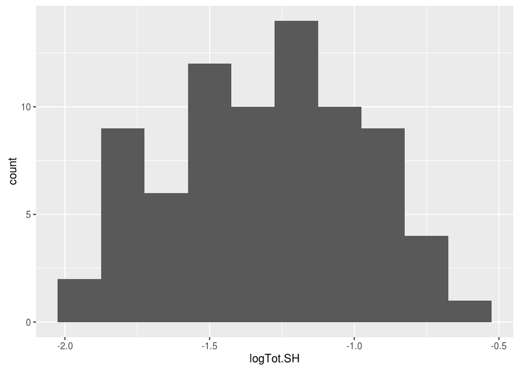

```r
    HistoSH<-qplot(logTot.SH, data=Ofav.data, binwidth=0.15)
    HistoSH
```

Histogram of log10(SH) by Combo (Nutrient Treatment * LGTB Treatment)

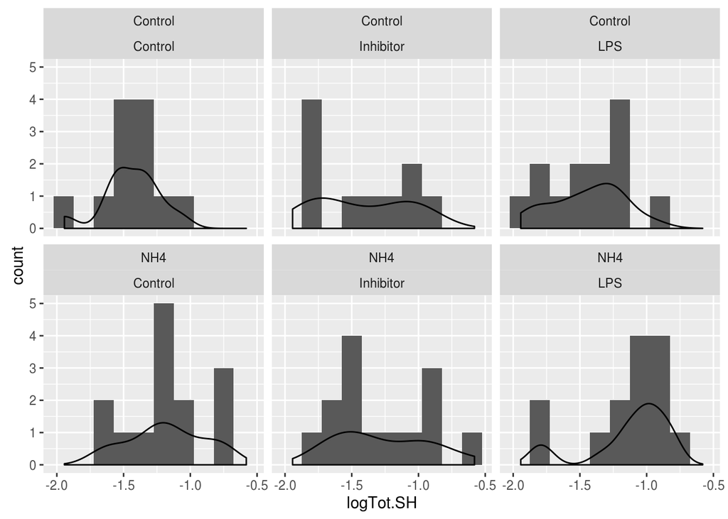

```r
    HistoSH +
      facet_wrap(Treatment~Treatment.2) +
      geom_density()
```

This is redundant information, but looking at these density plots I am a bit concerned about the SH cell ratios in Inhibitor, since the differences bw Controls and NH4 are not that clear

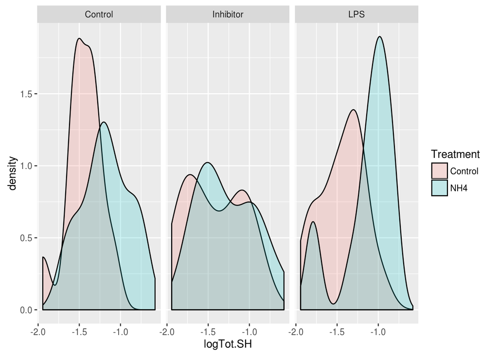

```r
    hist_Tre <- ggplot(Ofav.data, aes(x=logTot.SH, fill=Treatment))

    hist_Tre +
      geom_density(alpha = 0.2) + facet_grid(~Treatment.2)
```

#### 2.2 Boxplots

Consider that ggplot shows by default median values instead mean values

Boxplot SH by Nutrients:

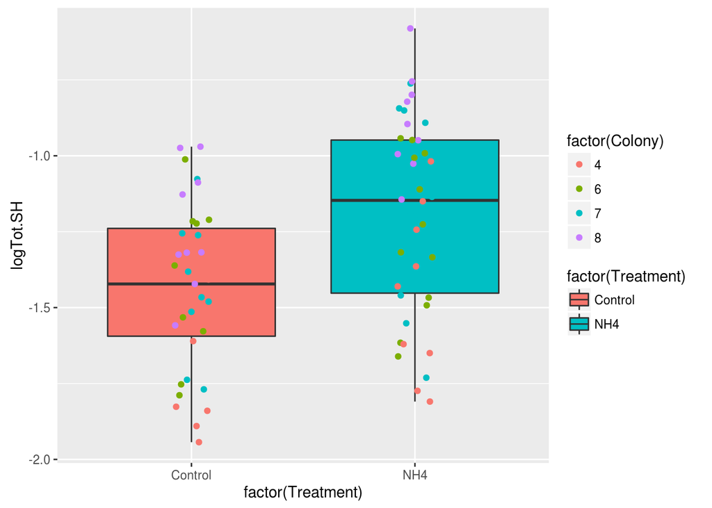

```r
    logSHTreatment <- ggplot(Ofav.data, aes(factor(Treatment), logTot.SH)) +
        geom_boxplot(aes(fill=factor(Treatment))) +
        geom_jitter(width = 0.2, aes(colour =factor(Colony)))

   logSHTreatment
```

Boxplot SH by Nutrients * TGFB:

```r
    logSHTreatment +
      facet_grid ((~Treatment.2))
```

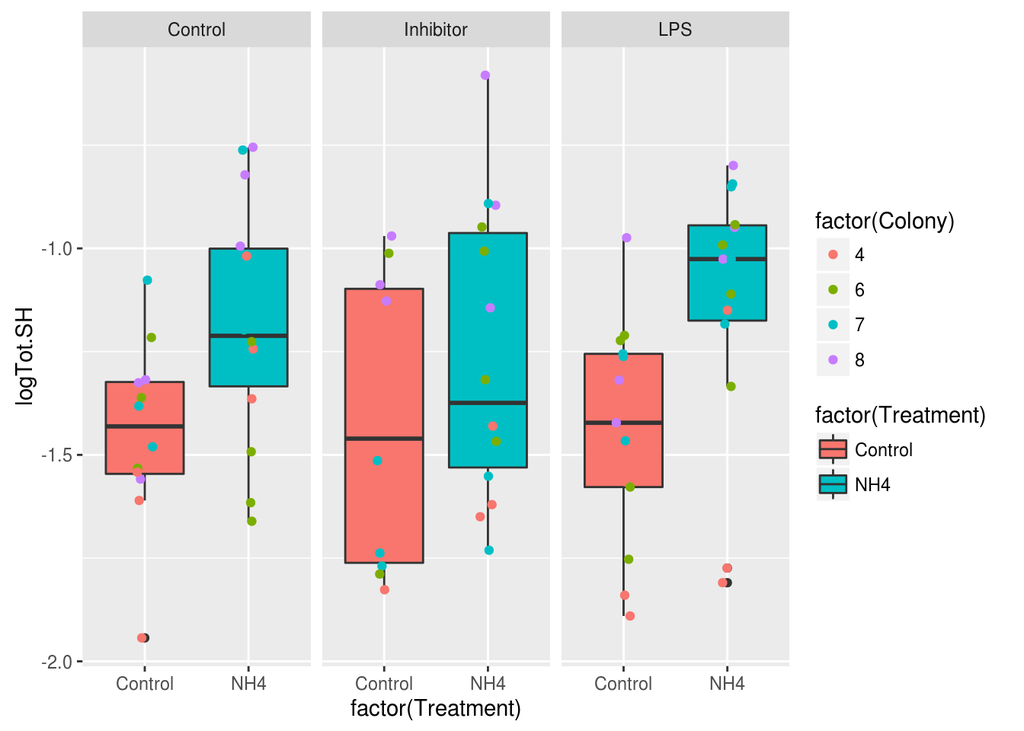

- Interestingly, Colony 4 has generally lower SH and 7 and 8 have higher.
- I think that 6 may be have lower values in the NH4 treatment because of the lower time with nutrients after mortallity?

If you want the mean values +- SD:

```
* Create a function to calculate de values:
```

```r
          min.mean.sd.max <- function(x) {
            r <- c(min(x), mean(x) - sd(x), mean(x), mean(x) + sd(x), max(x))
            names(r) <- c("ymin", "lower", "middle", "upper", "ymax")
            r
          }
```

```
* And plot using ggplot
```

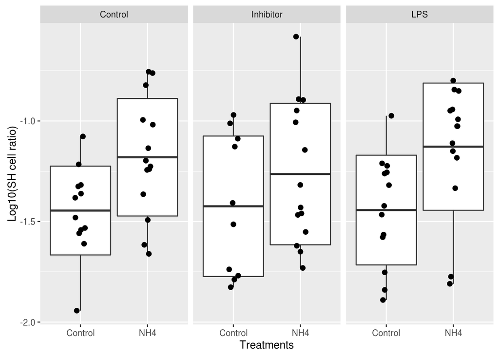

```r
      PlotMeanAndSD <- ggplot(aes(y = logTot.SH, x = factor(Treatment)), data = Ofav.data) +
                  facet_grid ((~Treatment.2))

      PlotMeanAndSD +
         stat_summary(fun.data = min.mean.sd.max, geom = "boxplot") +
         geom_jitter(position=position_jitter(width=.2), size=2) +
         xlab("Treatments") + ylab("Log10(SH cell ratio)")
```

Finally, let’s explore that possible colony effect!

```r
    logSHTreatment +
      facet_grid (~Colony)
```

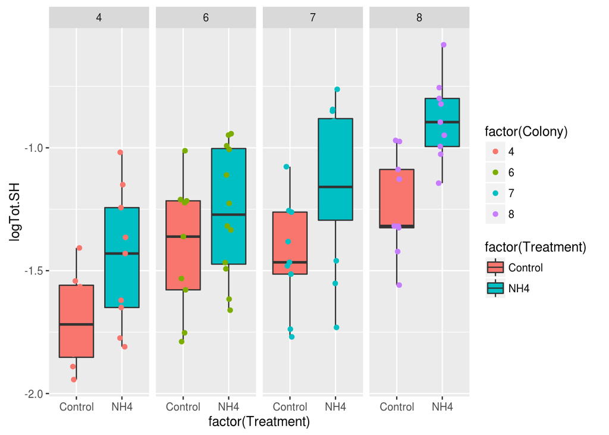

And… fuck, maybe consider to exclude colony 6 or to treat the SH cell ratio as a continous variable instead as a high/low category. See ANOVA at the end.

```r
    logSHTreatment +
      facet_grid (Treatment.2~Colony)
```

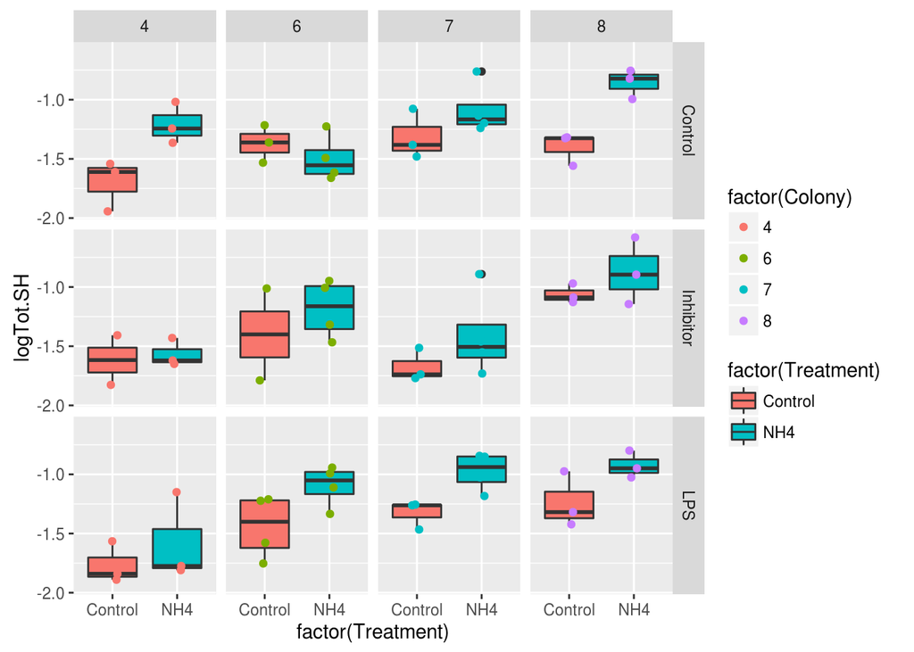

Possible problematic combinations:

- Colony 6 in Control
- Colony 4 in Inhibitor
- Colony 4 in LPS?

Explore later, check weird SH Values and new introduced cores in the NH4 treatmet.

### 3. ANOVAS

#### 1. One way ANOVA to test the effect of nutrients alone:

```r
    OnwWayANOVA<-aov(logTot.SH~Treatment, data=Ofav.data)
        summary(OnwWayANOVA)
```

```
##             Df Sum Sq Mean Sq F value   Pr(>F)
## Treatment    1  1.171  1.1712   13.15 0.000521 ***
## Residuals   75  6.680  0.0891
## ---
## Signif. codes:  0 '***' 0.001 '**' 0.01 '*' 0.05 '.' 0.1 ' ' 1
```

Great! Nutrients increased the SH cell ratio!

#### 2. Two Way ANOVA to test effects of Nutrients (Treatment) * TGFB (Treatment.2)

```r
    TwoWayANOVA<-aov(logTot.SH ~ Treatment*Treatment.2 , data=Ofav.data)
        summary(TwoWayANOVA)
```

```
##                       Df Sum Sq Mean Sq F value   Pr(>F)
## Treatment              1  1.171  1.1712  12.705 0.000657 ***
## Treatment.2            2  0.058  0.0288   0.313 0.732566
## Treatment:Treatment.2  2  0.077  0.0385   0.417 0.660421
## Residuals             71  6.545  0.0922
## ---
## Signif. codes:  0 '***' 0.001 '**' 0.01 '*' 0.05 '.' 0.1 ' ' 1
```

```r
        drop1(TwoWayANOVA,~.,test="F")
```

```
## Single term deletions
##
## Model:
## logTot.SH ~ Treatment * Treatment.2
##                       Df Sum of Sq    RSS     AIC F value Pr(>F)
## <none>                             6.5450 -177.81
## Treatment              1   0.45379 6.9988 -174.65  4.9227 0.0297 *
## Treatment.2            2   0.00290 6.5479 -181.78  0.0157 0.9844
## Treatment:Treatment.2  2   0.07694 6.6219 -180.91  0.4173 0.6604
## ---
## Signif. codes:  0 '***' 0.001 '**' 0.01 '*' 0.05 '.' 0.1 ' ' 1
```

ATENTION!!!! summary(ANOVA) and drop1(ANOVA) give different p values for the model. I have to investigate what the difference is, but in both cases Treatment (Nutrients) has a significant effect on the SH cell ratio while Treatment.2 (TGFB) does not, nor the interaction. Great!!!

However, I am afraid that the differences in the SH cell ratio in “Inhibitor” are not very strong. See graphs.

#### 3. One Way ANOVA within factor to test effects of Nutrients (Treatment)/ Colony

```r
    TwoFactorsLMcolony = lmer('logTot.SH~Treatment*Treatment.2 + (1|Colony/Treatment)', data=Ofav.data)
        print(anova(TwoFactorsLMcolony))
```

```
## Analysis of Variance Table of type III  with  Satterthwaite
## approximation for degrees of freedom
##                        Sum Sq Mean Sq NumDF  DenDF F.value    Pr(>F)
## Treatment             1.22799 1.22799     1 68.000 19.9703 3.054e-05 ***
## Treatment.2           0.06596 0.03298     2 67.979  0.5363    0.5874
## Treatment:Treatment.2 0.05076 0.02538     2 67.979  0.4128    0.6635
## ---
## Signif. codes:  0 '***' 0.001 '**' 0.01 '*' 0.05 '.' 0.1 ' ' 1
```

```r
        summary(TwoFactorsLMcolony)
```

```
## Linear mixed model fit by REML t-tests use Satterthwaite approximations
##   to degrees of freedom [lmerMod]
## Formula: logTot.SH ~ Treatment * Treatment.2 + (1 | Colony/Treatment)
##    Data: Ofav.data
##
## REML criterion at convergence: 26.6
##
## Scaled residuals:
##      Min       1Q   Median       3Q      Max
## -1.97062 -0.59511 -0.09402  0.70750  1.85688
##
## Random effects:
##  Groups           Name        Variance Std.Dev.
##  Treatment:Colony (Intercept) 0.00000  0.0000
##  Colony           (Intercept) 0.04131  0.2032
##  Residual                     0.06149  0.2480
## Number of obs: 77, groups:  Treatment:Colony, 8; Colony, 4
##
## Fixed effects:
##                                   Estimate Std. Error       df t value
## (Intercept)                       -1.44549    0.12430  5.67000 -11.629
## TreatmentNH4                       0.26505    0.09763 67.98000   2.715
## Treatment.2Inhibitor              -0.00471    0.10632 67.99000  -0.044
## Treatment.2LPS                     0.00426    0.09933 67.97000   0.043
## TreatmentNH4:Treatment.2Inhibitor -0.07869    0.14173 67.98000  -0.555
## TreatmentNH4:Treatment.2LPS        0.04832    0.13657 67.97000   0.354
##                                   Pr(>|t|)
## (Intercept)                       3.62e-05 ***
## TreatmentNH4                        0.0084 **
## Treatment.2Inhibitor                0.9648
## Treatment.2LPS                      0.9659
## TreatmentNH4:Treatment.2Inhibitor   0.5806
## TreatmentNH4:Treatment.2LPS         0.7246
## ---
## Signif. codes:  0 '***' 0.001 '**' 0.01 '*' 0.05 '.' 0.1 ' ' 1
##
## Correlation of Fixed Effects:
##             (Intr) TrtNH4 Trt.2I T.2LPS TNH4:T.2I
## TreatmntNH4 -0.422
## Trtmnt.2Inh -0.388  0.494
## Trtmnt.2LPS -0.415  0.529  0.484
## TrtNH4:T.2I  0.291 -0.688 -0.750 -0.363
## TNH4:T.2LPS  0.302 -0.714 -0.352 -0.727  0.491
```